# Project: Investigate a Dataset - [TMDb movie data]

- Introduction
- Data Wrangling
- Exploratory Data Analysis
- Conclusions

# Introduction

### Dataset Description

The dataset "tmdb-movies.csv" is derived from The Movie Database (TMDb) and comprises information on 10,000 movies. It includes details such as user ratings, revenue, cast, genres, and more.

### Data Dictionary (21 variables):

1-id: Unique identifier for each movie.

2-imdb_id: IMDb identifier for cross-referencing with the IMDb database.

3-popularity: Popularity score of the movie.

4-budget: Original budget of the movie.

5-revenue: Revenue generated by the movie.

6-original_title: The title of the movie.

7-cast: List of cast members, separated by pipe (|) characters.

8-homepage: URL of the movie's official website.

9-director: Director of the movie.

10-tagline: Tagline associated with the movie.

11-keywords: Keywords associated with the movie.

12-overview: Brief overview or summary of the movie.

13-runtime: Duration of the movie in minutes.

14-genres: Genres associated with the movie, separated by pipe (|) characters.

15-production_companies: Production companies involved in making the movie.

16-release_date: Date when the movie was released.

17-vote_count: Number of votes received by the movie.

18-vote_average: Average rating given to the movie by users.

19-release_year: Year when the movie was released.

20-budget_adj: Budget of the movie adjusted for inflation in terms of 2010 dollars.

21-revenue_adj: Revenue generated by the movie adjusted for inflation in terms of 2010 dollars.

### Question's for Analysis

1-what are the Top 10 highest popular movies?

2-what are the Top 10 highest rated movies?

3-is there a relationship between popularity and the vote_count?

4-what is the Average runtime?

5-which movie with Largest and Lowest Budget?

6-which movie with Largest and Lowest revenue?

7-Is there a correlation or relationship between the budget and revenue for all movies in the dataset?

8-Which Genre Has The Highest Release Of Movies

9-The relationship between Popularity and Profit?

10-who are The most famous directors?

```python
#import what i plan to use
import pandas as pd                      # for redeing and data proccesing
import numpy as np                       # for linear algebra
import os as os                          # for accessing directory structure
import datetime as dt
 # for visualization
import matplotlib.pyplot as plt
%matplotlib inline
import matplotlib.pylab as pylab
import seaborn as sns
plt.style.use('seaborn-colorblind')
params = {'legend.fontsize': 'x-large','figure.figsize': (15, 5),'axes.labelsize': 'x-large','axes.titlesize':'x-large',
          'xtick.labelsize':'x-large','ytick.labelsize':'x-large'}
pylab.rcParams.update(params)
```

## Data Wrangling

In this section of the report, I will load in the data, check for cleanliness, and then clean my dataset for analysis.

### General Properties

```python
df = pd.read_csv('tmdb-movies.csv', sep=',') ## load the data from the file
pd.set_option('display.max_columns',200)

df.head()# take a look at what the taple looks like
```

|  | id | imdb_id | popularity | budget | revenue | original_title | cast | homepage | director | tagline | keywords | overview | runtime | genres | production_companies | release_date | vote_count | vote_average | release_year | budget_adj | revenue_adj |
| --- | --- | --- | --- | --- | --- | --- | --- | --- | --- | --- | --- | --- | --- | --- | --- | --- | --- | --- | --- | --- | --- |
| 0 | 135397 | tt0369610 | 32.985763 | 150000000 | 1513528810 | Jurassic World | Chris Pratt\|Bryce Dallas Howard\|Irrfan Khan\|Vi... | http://www.jurassicworld.com/ | Colin Trevorrow | The park is open. | monster\|dna\|tyrannosaurus rex\|velociraptor\|island | Twenty-two years after the events of Jurassic ... | 124 | Action\|Adventure\|Science Fiction\|Thriller | Universal Studios\|Amblin Entertainment\|Legenda... | 6/9/15 | 5562 | 6.5 | 2015 | 1.379999e+08 | 1.392446e+09 |
| 1 | 76341 | tt1392190 | 28.419936 | 150000000 | 378436354 | Mad Max: Fury Road | Tom Hardy\|Charlize Theron\|Hugh Keays-Byrne\|Nic... | http://www.madmaxmovie.com/ | George Miller | What a Lovely Day. | future\|chase\|post-apocalyptic\|dystopia\|australia | An apocalyptic story set in the furthest reach... | 120 | Action\|Adventure\|Science Fiction\|Thriller | Village Roadshow Pictures\|Kennedy Miller Produ... | 5/13/15 | 6185 | 7.1 | 2015 | 1.379999e+08 | 3.481613e+08 |
| 2 | 262500 | tt2908446 | 13.112507 | 110000000 | 295238201 | Insurgent | Shailene Woodley\|Theo James\|Kate Winslet\|Ansel... | http://www.thedivergentseries.movie/#insurgent | Robert Schwentke | One Choice Can Destroy You | based on novel\|revolution\|dystopia\|sequel\|dyst... | Beatrice Prior must confront her inner demons ... | 119 | Adventure\|Science Fiction\|Thriller | Summit Entertainment\|Mandeville Films\|Red Wago... | 3/18/15 | 2480 | 6.3 | 2015 | 1.012000e+08 | 2.716190e+08 |
| 3 | 140607 | tt2488496 | 11.173104 | 200000000 | 2068178225 | Star Wars: The Force Awakens | Harrison Ford\|Mark Hamill\|Carrie Fisher\|Adam D... | http://www.starwars.com/films/star-wars-episod... | J.J. Abrams | Every generation has a story. | android\|spaceship\|jedi\|space opera\|3d | Thirty years after defeating the Galactic Empi... | 136 | Action\|Adventure\|Science Fiction\|Fantasy | Lucasfilm\|Truenorth Productions\|Bad Robot | 12/15/15 | 5292 | 7.5 | 2015 | 1.839999e+08 | 1.902723e+09 |
| 4 | 168259 | tt2820852 | 9.335014 | 190000000 | 1506249360 | Furious 7 | Vin Diesel\|Paul Walker\|Jason Statham\|Michelle ... | http://www.furious7.com/ | James Wan | Vengeance Hits Home | car race\|speed\|revenge\|suspense\|car | Deckard Shaw seeks revenge against Dominic Tor... | 137 | Action\|Crime\|Thriller | Universal Pictures\|Original Film\|Media Rights ... | 4/1/15 | 2947 | 7.3 | 2015 | 1.747999e+08 | 1.385749e+09 |

```python
df.tail()
```

|  | id | imdb_id | popularity | budget | revenue | original_title | cast | homepage | director | tagline | keywords | overview | runtime | genres | production_companies | release_date | vote_count | vote_average | release_year | budget_adj | revenue_adj |
| --- | --- | --- | --- | --- | --- | --- | --- | --- | --- | --- | --- | --- | --- | --- | --- | --- | --- | --- | --- | --- | --- |
| 10861 | 21 | tt0060371 | 0.080598 | 0 | 0 | The Endless Summer | Michael Hynson\|Robert August\|Lord 'Tally Ho' B... | NaN | Bruce Brown | NaN | surfer\|surfboard\|surfing | The Endless Summer, by Bruce Brown, is one of ... | 95 | Documentary | Bruce Brown Films | 6/15/66 | 11 | 7.4 | 1966 | 0.000000 | 0.0 |
| 10862 | 20379 | tt0060472 | 0.065543 | 0 | 0 | Grand Prix | James Garner\|Eva Marie Saint\|Yves Montand\|Tosh... | NaN | John Frankenheimer | Cinerama sweeps YOU into a drama of speed and ... | car race\|racing\|formula 1 | Grand Prix driver Pete Aron is fired by his te... | 176 | Action\|Adventure\|Drama | Cherokee Productions\|Joel Productions\|Douglas ... | 12/21/66 | 20 | 5.7 | 1966 | 0.000000 | 0.0 |
| 10863 | 39768 | tt0060161 | 0.065141 | 0 | 0 | Beregis Avtomobilya | Innokentiy Smoktunovskiy\|Oleg Efremov\|Georgi Z... | NaN | Eldar Ryazanov | NaN | car\|trolley\|stealing car | An insurance agent who moonlights as a carthie... | 94 | Mystery\|Comedy | Mosfilm | 1/1/66 | 11 | 6.5 | 1966 | 0.000000 | 0.0 |
| 10864 | 21449 | tt0061177 | 0.064317 | 0 | 0 | What's Up, Tiger Lily? | Tatsuya Mihashi\|Akiko Wakabayashi\|Mie Hama\|Joh... | NaN | Woody Allen | WOODY ALLEN STRIKES BACK! | spoof | In comic Woody Allen's film debut, he took the... | 80 | Action\|Comedy | Benedict Pictures Corp. | 11/2/66 | 22 | 5.4 | 1966 | 0.000000 | 0.0 |
| 10865 | 22293 | tt0060666 | 0.035919 | 19000 | 0 | Manos: The Hands of Fate | Harold P. Warren\|Tom Neyman\|John Reynolds\|Dian... | NaN | Harold P. Warren | It's Shocking! It's Beyond Your Imagination! | fire\|gun\|drive\|sacrifice\|flashlight | A family gets lost on the road and stumbles up... | 74 | Horror | Norm-Iris | 11/15/66 | 15 | 1.5 | 1966 | 127642.279154 | 0.0 |

```python
#Exploreing the shape of data
df.shape
```

```
(10866, 21)
```

#### so we have 10866 rows(ID) and 21 columns

```python
list(df.columns) ## to take look at the coulmns
```

```
['id',
 'imdb_id',
 'popularity',
 'budget',
 'revenue',
 'original_title',
 'cast',
 'homepage',
 'director',
 'tagline',
 'keywords',
 'overview',
 'runtime',
 'genres',
 'production_companies',
 'release_date',
 'vote_count',
 'vote_average',
 'release_year',
 'budget_adj',
 'revenue_adj']
```

```python
df.count()
```

```
id                      10866
imdb_id                 10856
popularity              10866
budget                  10866
revenue                 10866
original_title          10866
cast                    10790
homepage                 2936
director                10822
tagline                  8042
keywords                 9373
overview                10862
runtime                 10866
genres                  10843
production_companies     9836
release_date            10866
vote_count              10866
vote_average            10866
release_year            10866
budget_adj              10866
revenue_adj             10866
dtype: int64
```

```python
df.info()
```

```
<class 'pandas.core.frame.DataFrame'>
RangeIndex: 10866 entries, 0 to 10865
Data columns (total 21 columns):
 #   Column                Non-Null Count  Dtype
---  ------                --------------  -----
 0   id                    10866 non-null  int64
 1   imdb_id               10856 non-null  object
 2   popularity            10866 non-null  float64
 3   budget                10866 non-null  int64
 4   revenue               10866 non-null  int64
 5   original_title        10866 non-null  object
 6   cast                  10790 non-null  object
 7   homepage              2936 non-null   object
 8   director              10822 non-null  object
 9   tagline               8042 non-null   object
 10  keywords              9373 non-null   object
 11  overview              10862 non-null  object
 12  runtime               10866 non-null  int64
 13  genres                10843 non-null  object
 14  production_companies  9836 non-null   object
 15  release_date          10866 non-null  object
 16  vote_count            10866 non-null  int64
 17  vote_average          10866 non-null  float64
 18  release_year          10866 non-null  int64
 19  budget_adj            10866 non-null  float64
 20  revenue_adj           10866 non-null  float64
dtypes: float64(4), int64(6), object(11)
memory usage: 1.7+ MB
```

```python
df.duplicated().sum()
```

```
1
```

#### so it has nulls and only one duplicate

```python
df.isnull().sum()
```

```
id                         0
imdb_id                   10
popularity                 0
budget                     0
revenue                    0
original_title             0
cast                      76
homepage                7930
director                  44
tagline                 2824
keywords                1493
overview                   4
runtime                    0
genres                    23
production_companies    1030
release_date               0
vote_count                 0
vote_average               0
release_year               0
budget_adj                 0
revenue_adj                0
dtype: int64
```

#### ther is some uninmportant column like: homepage, keywords

```python
df.describe()
```

|  | id | popularity | budget | revenue | runtime | vote_count | vote_average | release_year | budget_adj | revenue_adj |
| --- | --- | --- | --- | --- | --- | --- | --- | --- | --- | --- |
| count | 10866.000000 | 10866.000000 | 1.086600e+04 | 1.086600e+04 | 10866.000000 | 10866.000000 | 10866.000000 | 10866.000000 | 1.086600e+04 | 1.086600e+04 |
| mean | 66064.177434 | 0.646441 | 1.462570e+07 | 3.982332e+07 | 102.070863 | 217.389748 | 5.974922 | 2001.322658 | 1.755104e+07 | 5.136436e+07 |
| std | 92130.136561 | 1.000185 | 3.091321e+07 | 1.170035e+08 | 31.381405 | 575.619058 | 0.935142 | 12.812941 | 3.430616e+07 | 1.446325e+08 |
| min | 5.000000 | 0.000065 | 0.000000e+00 | 0.000000e+00 | 0.000000 | 10.000000 | 1.500000 | 1960.000000 | 0.000000e+00 | 0.000000e+00 |
| 25% | 10596.250000 | 0.207583 | 0.000000e+00 | 0.000000e+00 | 90.000000 | 17.000000 | 5.400000 | 1995.000000 | 0.000000e+00 | 0.000000e+00 |
| 50% | 20669.000000 | 0.383856 | 0.000000e+00 | 0.000000e+00 | 99.000000 | 38.000000 | 6.000000 | 2006.000000 | 0.000000e+00 | 0.000000e+00 |
| 75% | 75610.000000 | 0.713817 | 1.500000e+07 | 2.400000e+07 | 111.000000 | 145.750000 | 6.600000 | 2011.000000 | 2.085325e+07 | 3.369710e+07 |
| max | 417859.000000 | 32.985763 | 4.250000e+08 | 2.781506e+09 | 900.000000 | 9767.000000 | 9.200000 | 2015.000000 | 4.250000e+08 | 2.827124e+09 |

```python
df.nunique()
```

```
id                      10865
imdb_id                 10855
popularity              10814
budget                    557
revenue                  4702
original_title          10571
cast                    10719
homepage                 2896
director                 5067
tagline                  7997
keywords                 8804
overview                10847
runtime                   247
genres                   2039
production_companies     7445
release_date             5909
vote_count               1289
vote_average               72
release_year               56
budget_adj               2614
revenue_adj              4840
dtype: int64
```

#### id unique (10865)

```python
df.original_title.duplicated().sum()
```

```
295
```

```python
df.loc[df.original_title.duplicated(keep='first'), :]
```

|  | id | imdb_id | popularity | budget | revenue | original_title | cast | homepage | director | tagline | keywords | overview | runtime | genres | production_companies | release_date | vote_count | vote_average | release_year | budget_adj | revenue_adj |
| --- | --- | --- | --- | --- | --- | --- | --- | --- | --- | --- | --- | --- | --- | --- | --- | --- | --- | --- | --- | --- | --- |
| 1133 | 281778 | tt3297792 | 0.188264 | 0 | 0 | Survivor | Danielle Chuchran\|Kevin Sorbo\|Rocky Myers\|Ruby... | http://www.arrowstormentertainment.com/#!survi... | John Lyde | Alone. Stranded. Deadly | survivor | During their search for a habitable planet the... | 93 | Science Fiction\|Action\|Fantasy | Arrowstorm Entertainment | 7/22/14 | 23 | 4.9 | 2014 | 0.000000e+00 | 0.000000e+00 |
| 1194 | 296626 | tt3534842 | 0.132764 | 0 | 0 | Finders Keepers | Jaime Pressly\|Kylie Rogers\|Tobin Bell\|Patrick ... | NaN | Alexander Yellen | NaN | profession\|evil doll\|possession\|murder\|problem... | A haunted doll teaches one little girl why chi... | 85 | Mystery\|Thriller\|Horror | HFD Productions\|Hybrid LLC | 10/18/14 | 33 | 4.8 | 2014 | 0.000000e+00 | 0.000000e+00 |
| 1349 | 42222 | tt0076245 | 0.398651 | 0 | 0 | Julia | Jane Fonda\|Vanessa Redgrave\|Jason Robards\|Maxi... | NaN | Fred Zinnemann | Through It All, Friendship Prevailed. | friends\|playwright | JULIA covers the 1930s when Lillian attained f... | 117 | Drama | Twentieth Century Fox Film Corporation | 10/2/77 | 10 | 5.0 | 1977 | 0.000000e+00 | 0.000000e+00 |
| 1440 | 7445 | tt0765010 | 1.223786 | 26000000 | 43318349 | Brothers | Tobey Maguire\|Jake Gyllenhaal\|Natalie Portman\|... | NaN | Jim Sheridan | There are two sides to every family. | brother brother relationship\|brother-in-law\|lo... | When his helicopter goes down during his fourt... | 104 | Drama\|Thriller\|War | Lionsgate\|Relativity Media\|Sighvatsson Films\|M... | 1/27/09 | 381 | 6.7 | 2009 | 2.642641e+07 | 4.402879e+07 |
| 1513 | 62320 | tt1014762 | 0.688361 | 0 | 0 | Home | Glenn Close\|Yann Arthus-Bertrand\|Jacques Gambl... | http://www.homethemovie.org/ | Yann Arthus-Bertrand | A Stunning Visual Portrayal of Earth | climate change\|earth\|global warming\|water poll... | With aerial footage from 54 countries, Home is... | 95 | Documentary | Europa Corp.\|ElzÃ©vir Films\|France 2 (FR2) | 6/3/09 | 109 | 7.8 | 2009 | 0.000000e+00 | 0.000000e+00 |
| ... | ... | ... | ... | ... | ... | ... | ... | ... | ... | ... | ... | ... | ... | ... | ... | ... | ... | ... | ... | ... | ... |
| 10818 | 39995 | tt0079482 | 0.047645 | 0 | 0 | Long Weekend | John Hargreaves\|Briony Behets\|Mike McEwen\|Roy ... | NaN | Colin Eggleston | Their crime was against nature. Nature found t... | beach\|camping\|attack\|nature | When a suburban couple go camping for the week... | 92 | Horror\|Thriller\|Mystery | The Australian Film Commission\|Victorian Film\|... | 10/14/78 | 17 | 6.1 | 1978 | 0.000000e+00 | 0.000000e+00 |
| 10827 | 2661 | tt0060153 | 0.410366 | 1377800 | 0 | Batman | Adam West\|Burt Ward\|Cesar Romero\|Burgess Mered... | NaN | Leslie H. Martinson | He's Here Big As Life In A Real Bat-Epic | submarine\|dc comics\|shark attack\|shark\|shark r... | The Dynamic Duo faces four super-villains who ... | 105 | Family\|Adventure\|Comedy\|Science Fiction\|Crime | Twentieth Century Fox Film Corporation\|DC Comi... | 7/30/66 | 99 | 5.9 | 1966 | 9.256081e+06 | 0.000000e+00 |
| 10849 | 28270 | tt0060445 | 0.206537 | 0 | 0 | Gambit | Michael Caine\|Shirley MacLaine\|Herbert Lom\|Joh... | NaN | Ronald Neame | Shirley MacLaine raises Michael Caine! | master thief | Harry Dean (Michael Caine) has a perfect plan ... | 109 | Action\|Comedy\|Crime | Universal Pictures | 12/16/66 | 14 | 6.1 | 1966 | 0.000000e+00 | 0.000000e+00 |
| 10853 | 15598 | tt0060086 | 0.163592 | 0 | 0 | Alfie | Michael Caine\|Shelley Winters\|Millicent Martin... | NaN | Lewis Gilbert | Is any man an Alfie? Ask any girl! | womanizer\|playboy | The film tells the story of a young man who le... | 114 | Comedy\|Drama\|Romance | NaN | 3/29/66 | 26 | 6.2 | 1966 | 0.000000e+00 | 0.000000e+00 |
| 10854 | 31602 | tt0060232 | 0.146402 | 0 | 0 | The Chase | Marlon Brando\|Jane Fonda\|Robert Redford\|E.G. M... | NaN | Arthur Penn | The chase is on! | sheriff\|house party\|man hunt\|junkyard\|jump fro... | Most everyone in town thinks that Sheriff Cald... | 135 | Thriller\|Drama\|Crime | Horizon Pictures\|Columbia Pictures Corporation | 2/17/66 | 17 | 6.0 | 1966 | 0.000000e+00 | 0.000000e+00 |

295 rows × 21 columns

### Data Cleaning

```python
df.release_date = pd.to_datetime(df.release_date) # convert the 'release_date'  to datetime


df.runtime = df.runtime.astype('int64') # to make sure ,convert the 'runtime' column to int
```

#### Remove Duplicates

```python
df.drop_duplicates(inplace=True) # drop any duplicates
```

```python
df.duplicated().sum().any() # check for any duplicates
```

```
False
```

```python
df.duplicated().sum() # check for any duplicates
```

```
0
```

```python
df.original_title.drop_duplicates(keep='last',inplace=False)
df.original_title.duplicated().sum()
```

```
294
```

#### Delete uninmportant columns

```python
# We said that unimportnat column are  (homepage),(keywords) so we will drop it
df = df.drop('homepage', axis = 1)
df = df.drop('keywords', axis = 1)
```

#### now need to fill zero values cells i will fill it by the mean value of each column

```python
def fill_zero_values(column): # def founction to fill the values in each coulmn with it's mean
    df[column] = df[column].replace(0,df[column].mean())

fill_zero_values('budget')
fill_zero_values('popularity')
fill_zero_values('revenue')
fill_zero_values('runtime')
fill_zero_values('vote_average')
fill_zero_values('vote_count')
fill_zero_values('budget_adj')
fill_zero_values('revenue_adj')
```

#### now drop the the NaN cells from the dataset

```python
df.dropna(inplace=True)# to drop
```

```python
df.isnull().sum()# to cheack th null
```

```
id                      0
imdb_id                 0
popularity              0
budget                  0
revenue                 0
original_title          0
cast                    0
director                0
tagline                 0
overview                0
runtime                 0
genres                  0
production_companies    0
release_date            0
vote_count              0
vote_average            0
release_year            0
budget_adj              0
revenue_adj             0
dtype: int64
```

```python
df.head()
```

|  | id | imdb_id | popularity | budget | revenue | original_title | cast | director | tagline | overview | runtime | genres | production_companies | release_date | vote_count | vote_average | release_year | budget_adj | revenue_adj |
| --- | --- | --- | --- | --- | --- | --- | --- | --- | --- | --- | --- | --- | --- | --- | --- | --- | --- | --- | --- |
| 0 | 135397 | tt0369610 | 32.985763 | 150000000.0 | 1.513529e+09 | Jurassic World | Chris Pratt\|Bryce Dallas Howard\|Irrfan Khan\|Vi... | Colin Trevorrow | The park is open. | Twenty-two years after the events of Jurassic ... | 124.0 | Action\|Adventure\|Science Fiction\|Thriller | Universal Studios\|Amblin Entertainment\|Legenda... | 2015-06-09 | 5562 | 6.5 | 2015 | 1.379999e+08 | 1.392446e+09 |
| 1 | 76341 | tt1392190 | 28.419936 | 150000000.0 | 3.784364e+08 | Mad Max: Fury Road | Tom Hardy\|Charlize Theron\|Hugh Keays-Byrne\|Nic... | George Miller | What a Lovely Day. | An apocalyptic story set in the furthest reach... | 120.0 | Action\|Adventure\|Science Fiction\|Thriller | Village Roadshow Pictures\|Kennedy Miller Produ... | 2015-05-13 | 6185 | 7.1 | 2015 | 1.379999e+08 | 3.481613e+08 |
| 2 | 262500 | tt2908446 | 13.112507 | 110000000.0 | 2.952382e+08 | Insurgent | Shailene Woodley\|Theo James\|Kate Winslet\|Ansel... | Robert Schwentke | One Choice Can Destroy You | Beatrice Prior must confront her inner demons ... | 119.0 | Adventure\|Science Fiction\|Thriller | Summit Entertainment\|Mandeville Films\|Red Wago... | 2015-03-18 | 2480 | 6.3 | 2015 | 1.012000e+08 | 2.716190e+08 |
| 3 | 140607 | tt2488496 | 11.173104 | 200000000.0 | 2.068178e+09 | Star Wars: The Force Awakens | Harrison Ford\|Mark Hamill\|Carrie Fisher\|Adam D... | J.J. Abrams | Every generation has a story. | Thirty years after defeating the Galactic Empi... | 136.0 | Action\|Adventure\|Science Fiction\|Fantasy | Lucasfilm\|Truenorth Productions\|Bad Robot | 2015-12-15 | 5292 | 7.5 | 2015 | 1.839999e+08 | 1.902723e+09 |
| 4 | 168259 | tt2820852 | 9.335014 | 190000000.0 | 1.506249e+09 | Furious 7 | Vin Diesel\|Paul Walker\|Jason Statham\|Michelle ... | James Wan | Vengeance Hits Home | Deckard Shaw seeks revenge against Dominic Tor... | 137.0 | Action\|Crime\|Thriller | Universal Pictures\|Original Film\|Media Rights ... | 2015-04-01 | 2947 | 7.3 | 2015 | 1.747999e+08 | 1.385749e+09 |

```python
df.shape
```

```
(7634, 19)
```

```python
df.info()
```

```
<class 'pandas.core.frame.DataFrame'>
Int64Index: 7634 entries, 0 to 10865
Data columns (total 19 columns):
 #   Column                Non-Null Count  Dtype
---  ------                --------------  -----
 0   id                    7634 non-null   int64
 1   imdb_id               7634 non-null   object
 2   popularity            7634 non-null   float64
 3   budget                7634 non-null   float64
 4   revenue               7634 non-null   float64
 5   original_title        7634 non-null   object
 6   cast                  7634 non-null   object
 7   director              7634 non-null   object
 8   tagline               7634 non-null   object
 9   overview              7634 non-null   object
 10  runtime               7634 non-null   float64
 11  genres                7634 non-null   object
 12  production_companies  7634 non-null   object
 13  release_date          7634 non-null   datetime64[ns]
 14  vote_count            7634 non-null   int64
 15  vote_average          7634 non-null   float64
 16  release_year          7634 non-null   int64
 17  budget_adj            7634 non-null   float64
 18  revenue_adj           7634 non-null   float64
dtypes: datetime64[ns](1), float64(7), int64(3), object(8)
memory usage: 1.2+ MB
```

## Exploratory Data Analysis

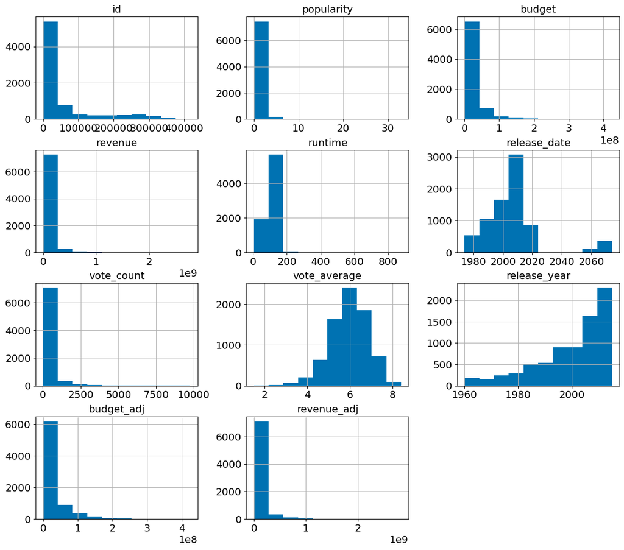

```python
df.hist(figsize=(15,13));
```

### Q1) Top 10 highest popular movies?

```python
top_10 = df['popularity'].nlargest(10).index # to get the Top 10 highest popular movies
df.loc[top_10]
```

|  | id | imdb_id | popularity | budget | revenue | original_title | cast | director | tagline | overview | runtime | genres | production_companies | release_date | vote_count | vote_average | release_year | budget_adj | revenue_adj |
| --- | --- | --- | --- | --- | --- | --- | --- | --- | --- | --- | --- | --- | --- | --- | --- | --- | --- | --- | --- |
| 0 | 135397 | tt0369610 | 32.985763 | 150000000.0 | 1.513529e+09 | Jurassic World | Chris Pratt\|Bryce Dallas Howard\|Irrfan Khan\|Vi... | Colin Trevorrow | The park is open. | Twenty-two years after the events of Jurassic ... | 124.0 | Action\|Adventure\|Science Fiction\|Thriller | Universal Studios\|Amblin Entertainment\|Legenda... | 2015-06-09 | 5562 | 6.5 | 2015 | 1.379999e+08 | 1.392446e+09 |
| 1 | 76341 | tt1392190 | 28.419936 | 150000000.0 | 3.784364e+08 | Mad Max: Fury Road | Tom Hardy\|Charlize Theron\|Hugh Keays-Byrne\|Nic... | George Miller | What a Lovely Day. | An apocalyptic story set in the furthest reach... | 120.0 | Action\|Adventure\|Science Fiction\|Thriller | Village Roadshow Pictures\|Kennedy Miller Produ... | 2015-05-13 | 6185 | 7.1 | 2015 | 1.379999e+08 | 3.481613e+08 |
| 629 | 157336 | tt0816692 | 24.949134 | 165000000.0 | 6.217525e+08 | Interstellar | Matthew McConaughey\|Jessica Chastain\|Anne Hath... | Christopher Nolan | Mankind was born on Earth. It was never meant ... | Interstellar chronicles the adventures of a gr... | 169.0 | Adventure\|Drama\|Science Fiction | Paramount Pictures\|Legendary Pictures\|Warner B... | 2014-11-05 | 6498 | 8.0 | 2014 | 1.519800e+08 | 5.726906e+08 |
| 630 | 118340 | tt2015381 | 14.311205 | 170000000.0 | 7.733124e+08 | Guardians of the Galaxy | Chris Pratt\|Zoe Saldana\|Dave Bautista\|Vin Dies... | James Gunn | All heroes start somewhere. | Light years from Earth, 26 years after being a... | 121.0 | Action\|Science Fiction\|Adventure | Marvel Studios\|Moving Picture Company (MPC)\|Bu... | 2014-07-30 | 5612 | 7.9 | 2014 | 1.565855e+08 | 7.122911e+08 |
| 2 | 262500 | tt2908446 | 13.112507 | 110000000.0 | 2.952382e+08 | Insurgent | Shailene Woodley\|Theo James\|Kate Winslet\|Ansel... | Robert Schwentke | One Choice Can Destroy You | Beatrice Prior must confront her inner demons ... | 119.0 | Adventure\|Science Fiction\|Thriller | Summit Entertainment\|Mandeville Films\|Red Wago... | 2015-03-18 | 2480 | 6.3 | 2015 | 1.012000e+08 | 2.716190e+08 |
| 631 | 100402 | tt1843866 | 12.971027 | 170000000.0 | 7.147666e+08 | Captain America: The Winter Soldier | Chris Evans\|Scarlett Johansson\|Sebastian Stan\|... | Joe Russo\|Anthony Russo | In heroes we trust. | After the cataclysmic events in New York with ... | 136.0 | Action\|Adventure\|Science Fiction | Marvel Studios | 2014-03-20 | 3848 | 7.6 | 2014 | 1.565855e+08 | 6.583651e+08 |
| 1329 | 11 | tt0076759 | 12.037933 | 11000000.0 | 7.753980e+08 | Star Wars | Mark Hamill\|Harrison Ford\|Carrie Fisher\|Peter ... | George Lucas | A long time ago in a galaxy far, far away... | Princess Leia is captured and held hostage by ... | 121.0 | Adventure\|Action\|Science Fiction | Lucasfilm\|Twentieth Century Fox Film Corporation | 1977-03-20 | 4428 | 7.9 | 1977 | 3.957559e+07 | 2.789712e+09 |
| 632 | 245891 | tt2911666 | 11.422751 | 20000000.0 | 7.873990e+07 | John Wick | Keanu Reeves\|Michael Nyqvist\|Alfie Allen\|Wille... | Chad Stahelski\|David Leitch | Don't set him off. | After the sudden death of his beloved wife, Jo... | 101.0 | Action\|Thriller | Thunder Road Pictures\|Warner Bros.\|87Eleven\|De... | 2014-10-22 | 2712 | 7.0 | 2014 | 1.842182e+07 | 7.252661e+07 |
| 3 | 140607 | tt2488496 | 11.173104 | 200000000.0 | 2.068178e+09 | Star Wars: The Force Awakens | Harrison Ford\|Mark Hamill\|Carrie Fisher\|Adam D... | J.J. Abrams | Every generation has a story. | Thirty years after defeating the Galactic Empi... | 136.0 | Action\|Adventure\|Science Fiction\|Fantasy | Lucasfilm\|Truenorth Productions\|Bad Robot | 2015-12-15 | 5292 | 7.5 | 2015 | 1.839999e+08 | 1.902723e+09 |
| 633 | 131631 | tt1951265 | 10.739009 | 125000000.0 | 7.521002e+08 | The Hunger Games: Mockingjay - Part 1 | Jennifer Lawrence\|Josh Hutcherson\|Liam Hemswor... | Francis Lawrence | Fire burns brighter in the darkness | Katniss Everdeen reluctantly becomes the symbo... | 123.0 | Science Fiction\|Adventure\|Thriller | Lionsgate\|Color Force | 2014-11-18 | 3590 | 6.6 | 2014 | 1.151364e+08 | 6.927528e+08 |

1-Jurassic World

2-Mad Max: Fury Road

10-The Hunger Games: Mockingjay - Part 1

### Q2) Top 10 highest rated movies?

```python
top_10 = df['vote_average'].nlargest(10).index  # to get the Top 10 highest rated movies
df.loc[top_10]
```

|  | id | imdb_id | popularity | budget | revenue | original_title | cast | director | tagline | overview | runtime | genres | production_companies | release_date | vote_count | vote_average | release_year | budget_adj | revenue_adj |
| --- | --- | --- | --- | --- | --- | --- | --- | --- | --- | --- | --- | --- | --- | --- | --- | --- | --- | --- | --- |
| 609 | 321640 | tt4299972 | 0.033378 | 1.462429e+07 | 3.982690e+07 | The Jinx: The Life and Deaths of Robert Durst | Robert Durst\|Andrew Jarecki\|Marc Smerling\|Zach... | Andrew Jarecki | Four Decades. Three Murders. And One Very Rich... | Robert Durst, scion of one of New Yorkâ€™s bil... | 240.0 | Documentary | Blumhouse Productions\|Hit the Ground Running F... | 2015-02-08 | 72 | 8.4 | 2015 | 1.754989e+07 | 5.136900e+07 |
| 4178 | 278 | tt0111161 | 7.192039 | 2.500000e+07 | 2.834147e+07 | The Shawshank Redemption | Tim Robbins\|Morgan Freeman\|Bob Gunton\|William ... | Frank Darabont | Fear can hold you prisoner. Hope can set you f... | Framed in the 1940s for the double murder of h... | 142.0 | Drama\|Crime | Castle Rock Entertainment | 1994-09-10 | 5754 | 8.4 | 1994 | 3.677779e+07 | 4.169346e+07 |
| 7948 | 24128 | tt0088178 | 0.283191 | 1.200000e+06 | 4.978922e+06 | Stop Making Sense | David Byrne\|Tina Weymouth\|Chris Frantz\|Jerry H... | Jonathan Demme | Why stop making sense? Why a movie? Why a big ... | David Byrne walks onto the stage and does a so... | 88.0 | Documentary\|Music | Talking Heads\|Arnold Stiefel Company | 1984-11-16 | 23 | 8.4 | 1984 | 2.518850e+06 | 1.045097e+07 |
| 7269 | 238 | tt0068646 | 5.738034 | 6.000000e+06 | 2.450664e+08 | The Godfather | Marlon Brando\|Al Pacino\|James Caan\|Richard S. ... | Francis Ford Coppola | An offer you can't refuse. | Spanning the years 1945 to 1955, a chronicle o... | 175.0 | Drama\|Crime | Paramount Pictures\|Alfran Productions | 2072-03-15 | 3970 | 8.3 | 1972 | 3.128737e+07 | 1.277914e+09 |
| 650 | 244786 | tt2582802 | 4.780419 | 3.300000e+06 | 1.399309e+07 | Whiplash | Miles Teller\|J.K. Simmons\|Melissa Benoist\|Aust... | Damien Chazelle | The road to greatness can take you to the edge. | Under the direction of a ruthless instructor, ... | 105.0 | Drama\|Music | Bold Films\|Blumhouse Productions\|Right of Way ... | 2014-10-10 | 2372 | 8.2 | 2014 | 3.039600e+06 | 1.288891e+07 |
| 9315 | 20423 | tt0097372 | 0.163885 | 1.462429e+07 | 3.982690e+07 | For All Mankind | Jim Lovell\|Russell Schweickart\|Eugene Cernan\|M... | Al Reinert | A Film by Al Reinert | In July 1969, the space race ended when Apollo... | 80.0 | Documentary | Apollo Associates\|FAM Productions | 1989-01-01 | 16 | 8.2 | 1989 | 1.754989e+07 | 5.136900e+07 |
| 2389 | 55244 | tt1621444 | 0.052322 | 1.462429e+07 | 1.339650e+06 | Bill Cunningham New York | Bill Cunningham\|Tom Wolfe\|Anna Wintour\|Carmen ... | Richard Press | He who seeks beauty, will find it. | Chronicles a man who is obsessively interested... | 84.0 | Documentary | First Thought Films | 2010-03-24 | 16 | 8.1 | 2010 | 1.754989e+07 | 1.339650e+06 |
| 2409 | 550 | tt0137523 | 8.947905 | 6.300000e+07 | 1.008538e+08 | Fight Club | Edward Norton\|Brad Pitt\|Meat Loaf\|Jared Leto\|H... | David Fincher | How much can you know about yourself if you've... | A ticking-time-bomb insomniac and a slippery s... | 139.0 | Drama | Regency Enterprises\|Fox 2000 Pictures\|Taurus F... | 1999-10-14 | 5923 | 8.1 | 1999 | 8.247033e+07 | 1.320229e+08 |
| 2875 | 155 | tt0468569 | 8.466668 | 1.850000e+08 | 1.001922e+09 | The Dark Knight | Christian Bale\|Michael Caine\|Heath Ledger\|Aaro... | Christopher Nolan | Why So Serious? | Batman raises the stakes in his war on crime. ... | 152.0 | Drama\|Action\|Crime\|Thriller | DC Comics\|Legendary Pictures\|Warner Bros.\|Syncopy | 2008-07-16 | 8432 | 8.1 | 2008 | 1.873655e+08 | 1.014733e+09 |
| 3826 | 414419 | tt6019206 | 0.146477 | 3.000000e+07 | 3.982690e+07 | Kill Bill: The Whole Bloody Affair | Uma Thurman\|Lucy Liu\|Vivica A. Fox\|Daryl Hanna... | Quentin Tarantino | The bride is back for the final cut | Kill Bill: The Whole Bloody affair is a comple... | 247.0 | Crime\|Action | Miramax Films\|A Band Apart\|Super Cool ManChu | 2011-03-28 | 28 | 8.1 | 2011 | 2.908194e+07 | 5.136900e+07 |

tha top 10 reted:

1-The Jinx: The Life and Deaths of Robert Durst

2-The Shawshank Redemption

3-Stop Making Sense

4-The Godfather

5-Whiplash

6-For All Mankind

7-Bill Cunningham New York

8-Fight Club

9-The Dark Knight

10-Kill Bill: The Whole Bloody Affair

### Q3) is there a relation between popularity and vote_count?

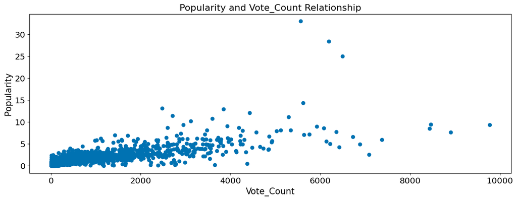

```python
#setup the lapels and the title for the scatter plot
plt.scatter(df.vote_count, df.popularity)
plt.xlabel('Vote_Count', fontsize=15)
plt.ylabel('Popularity', fontsize=15)
plt.title('Popularity and Vote_Count Relationship', fontsize= 16)
#for the figure size.
sns.set(rc={'figure.figsize':(6,4)})
sns.set_style("whitegrid")
```

#### Answer: yes and based on the distribution it is positive relationship

### Q4) what is the Average runtime?

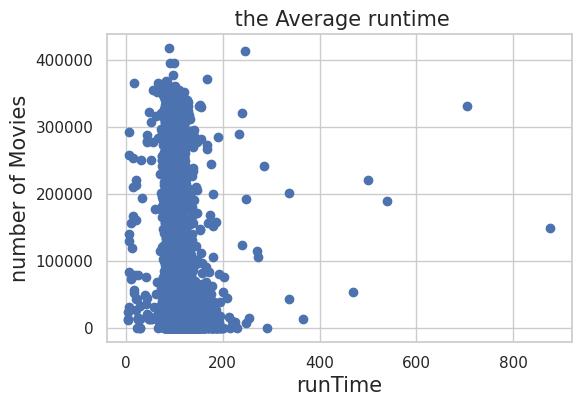

```python
#setup the lapels and the title for the scatter plot
plt.scatter(df.runtime, df.id)
plt.xlabel('runTime', fontsize=15)
plt.ylabel('number of Movies', fontsize=15)
plt.title(' the Average runtime', fontsize=15);

#for the figure size.
sns.set(rc={'figure.figsize':(6,4)})
sns.set_style("whitegrid")
```

#### like we see the Average runtime is between 100 and 150 mins

### Q5) which movie with Largest and Lowest Budget?

```python
def find_min_max(x):
    min_index = df[x].idxmin()    #function (idmin) to find the index of lowest profit movie.

    high_index = df[x].idxmax()   #function (idmax) to find the index of Highest profit movie.

    high = pd.DataFrame(df.loc[high_index,:])
    low = pd.DataFrame(df.loc[min_index,:])
    return pd.concat([high,low],axis = 1)
```

```python
# we use the founction above this cell to find the budget
find_min_max('budget')
```

|  | 2244 | 2618 |
| --- | --- | --- |
| id | 46528 | 39964 |
| imdb_id | tt1032751 | tt0120836 |
| popularity | 0.25054 | 0.090186 |
| budget | 425000000.0 | 1.0 |
| revenue | 11087569.0 | 100.0 |
| original_title | The Warrior's Way | Lost & Found |
| cast | Kate Bosworth\|Jang Dong-gun\|Geoffrey Rush\|Dann... | David Spade\|Sophie Marceau\|Ever Carradine\|Step... |
| director | Sngmoo Lee | Jeff Pollack |
| tagline | Assassin. Hero. Legend. | A comedy about a guy who would do anything to ... |
| overview | An Asian assassin (Dong-gun Jang) is forced to... | A comedy about finding your true love at any p... |
| runtime | 100.0 | 95.0 |
| genres | Adventure\|Fantasy\|Action\|Western\|Thriller | Comedy\|Romance |
| production_companies | Boram Entertainment Inc. | Alcon Entertainment\|Dinamo Entertainment |
| release_date | 2010-12-02 00:00:00 | 1999-04-23 00:00:00 |
| vote_count | 74 | 14 |
| vote_average | 6.4 | 4.8 |
| release_year | 2010 | 1999 |
| budget_adj | 425000000.0 | 1.309053 |
| revenue_adj | 11087569.0 | 130.905285 |

## --so after take a look into the taple we will see thet:

#### -the Largest Budget is: The Warrior's Way

#### -the Lowest Budget is: Lost & Found

### Q6)which movie with Largest and Lowest Revenue?

```python
# we use the same founction in Q5, to find the revenue
find_min_max('revenue')
```

|  | 1386 | 8142 |
| --- | --- | --- |
| id | 19995 | 2293 |
| imdb_id | tt0499549 | tt0113749 |
| popularity | 9.432768 | 0.552091 |
| budget | 237000000.0 | 6000000.0 |
| revenue | 2781505847.0 | 2.0 |
| original_title | Avatar | Mallrats |
| cast | Sam Worthington\|Zoe Saldana\|Sigourney Weaver\|S... | Jason Lee\|Jeremy London\|Shannen Doherty\|Claire... |
| director | James Cameron | Kevin Smith |
| tagline | Enter the World of Pandora. | They're not there to shop. They're not there t... |
| overview | In the 22nd century, a paraplegic Marine is di... | Both dumped by their girlfriends, two best fri... |
| runtime | 162.0 | 94.0 |
| genres | Action\|Adventure\|Fantasy\|Science Fiction | Romance\|Comedy |
| production_companies | Ingenious Film Partners\|Twentieth Century Fox ... | Gramercy Pictures\|Alphaville Films\|View Askew ... |
| release_date | 2009-12-10 00:00:00 | 1995-10-20 00:00:00 |
| vote_count | 8458 | 201 |
| vote_average | 7.1 | 6.8 |
| release_year | 2009 | 1995 |
| budget_adj | 240886902.887613 | 8585801.202642 |
| revenue_adj | 2827123750.41189 | 2.861934 |

## --so after take a look into the taple we will see thet:

#### -the Largest Revenue is: Avatar

#### -the Lowest Revenue is: Mallrats

### Q7) Is there a correlation or connection between the budget and revenue for all movies in the dataset?

```python
## make the process more easy get coulmns for each the :"all_revenue" ,"all_budget" and get the "profit"
df['all_revenue'] = df.revenue + df.revenue_adj
df['all_budget'] = df.budget + df.budget_adj
df['profit'] = df.all_revenue - df.all_budget
df.head()
```

|  | id | imdb_id | popularity | budget | revenue | original_title | cast | director | tagline | overview | runtime | genres | production_companies | release_date | vote_count | vote_average | release_year | budget_adj | revenue_adj | all_revenue | all_budget | profit |
| --- | --- | --- | --- | --- | --- | --- | --- | --- | --- | --- | --- | --- | --- | --- | --- | --- | --- | --- | --- | --- | --- | --- |
| 0 | 135397 | tt0369610 | 32.985763 | 150000000.0 | 1.513529e+09 | Jurassic World | Chris Pratt\|Bryce Dallas Howard\|Irrfan Khan\|Vi... | Colin Trevorrow | The park is open. | Twenty-two years after the events of Jurassic ... | 124.0 | Action\|Adventure\|Science Fiction\|Thriller | Universal Studios\|Amblin Entertainment\|Legenda... | 2015-06-09 | 5562 | 6.5 | 2015 | 1.379999e+08 | 1.392446e+09 | 2.905975e+09 | 2.879999e+08 | 2.617975e+09 |
| 1 | 76341 | tt1392190 | 28.419936 | 150000000.0 | 3.784364e+08 | Mad Max: Fury Road | Tom Hardy\|Charlize Theron\|Hugh Keays-Byrne\|Nic... | George Miller | What a Lovely Day. | An apocalyptic story set in the furthest reach... | 120.0 | Action\|Adventure\|Science Fiction\|Thriller | Village Roadshow Pictures\|Kennedy Miller Produ... | 2015-05-13 | 6185 | 7.1 | 2015 | 1.379999e+08 | 3.481613e+08 | 7.265976e+08 | 2.879999e+08 | 4.385977e+08 |
| 2 | 262500 | tt2908446 | 13.112507 | 110000000.0 | 2.952382e+08 | Insurgent | Shailene Woodley\|Theo James\|Kate Winslet\|Ansel... | Robert Schwentke | One Choice Can Destroy You | Beatrice Prior must confront her inner demons ... | 119.0 | Adventure\|Science Fiction\|Thriller | Summit Entertainment\|Mandeville Films\|Red Wago... | 2015-03-18 | 2480 | 6.3 | 2015 | 1.012000e+08 | 2.716190e+08 | 5.668572e+08 | 2.112000e+08 | 3.556573e+08 |
| 3 | 140607 | tt2488496 | 11.173104 | 200000000.0 | 2.068178e+09 | Star Wars: The Force Awakens | Harrison Ford\|Mark Hamill\|Carrie Fisher\|Adam D... | J.J. Abrams | Every generation has a story. | Thirty years after defeating the Galactic Empi... | 136.0 | Action\|Adventure\|Science Fiction\|Fantasy | Lucasfilm\|Truenorth Productions\|Bad Robot | 2015-12-15 | 5292 | 7.5 | 2015 | 1.839999e+08 | 1.902723e+09 | 3.970901e+09 | 3.839999e+08 | 3.586901e+09 |
| 4 | 168259 | tt2820852 | 9.335014 | 190000000.0 | 1.506249e+09 | Furious 7 | Vin Diesel\|Paul Walker\|Jason Statham\|Michelle ... | James Wan | Vengeance Hits Home | Deckard Shaw seeks revenge against Dominic Tor... | 137.0 | Action\|Crime\|Thriller | Universal Pictures\|Original Film\|Media Rights ... | 2015-04-01 | 2947 | 7.3 | 2015 | 1.747999e+08 | 1.385749e+09 | 2.891998e+09 | 3.647999e+08 | 2.527198e+09 |

```python
top_10 = df.all_revenue.nlargest(10).index # to get the highest 10 revnue movies
df.loc[top_10]
```

|  | id | imdb_id | popularity | budget | revenue | original_title | cast | director | tagline | overview | runtime | genres | production_companies | release_date | vote_count | vote_average | release_year | budget_adj | revenue_adj | all_revenue | all_budget | profit |
| --- | --- | --- | --- | --- | --- | --- | --- | --- | --- | --- | --- | --- | --- | --- | --- | --- | --- | --- | --- | --- | --- | --- |
| 1386 | 19995 | tt0499549 | 9.432768 | 237000000.0 | 2.781506e+09 | Avatar | Sam Worthington\|Zoe Saldana\|Sigourney Weaver\|S... | James Cameron | Enter the World of Pandora. | In the 22nd century, a paraplegic Marine is di... | 162.0 | Action\|Adventure\|Fantasy\|Science Fiction | Ingenious Film Partners\|Twentieth Century Fox ... | 2009-12-10 | 8458 | 7.1 | 2009 | 2.408869e+08 | 2.827124e+09 | 5.608630e+09 | 4.778869e+08 | 5.130743e+09 |
| 5231 | 597 | tt0120338 | 4.355219 | 200000000.0 | 1.845034e+09 | Titanic | Kate Winslet\|Leonardo DiCaprio\|Frances Fisher\|... | James Cameron | Nothing on Earth could come between them. | 84 years later, a 101-year-old woman named Ros... | 194.0 | Drama\|Romance\|Thriller | Paramount Pictures\|Twentieth Century Fox Film ... | 1997-11-18 | 4654 | 7.3 | 1997 | 2.716921e+08 | 2.506406e+09 | 4.351440e+09 | 4.716921e+08 | 3.879748e+09 |
| 3 | 140607 | tt2488496 | 11.173104 | 200000000.0 | 2.068178e+09 | Star Wars: The Force Awakens | Harrison Ford\|Mark Hamill\|Carrie Fisher\|Adam D... | J.J. Abrams | Every generation has a story. | Thirty years after defeating the Galactic Empi... | 136.0 | Action\|Adventure\|Science Fiction\|Fantasy | Lucasfilm\|Truenorth Productions\|Bad Robot | 2015-12-15 | 5292 | 7.5 | 2015 | 1.839999e+08 | 1.902723e+09 | 3.970901e+09 | 3.839999e+08 | 3.586901e+09 |
| 1329 | 11 | tt0076759 | 12.037933 | 11000000.0 | 7.753980e+08 | Star Wars | Mark Hamill\|Harrison Ford\|Carrie Fisher\|Peter ... | George Lucas | A long time ago in a galaxy far, far away... | Princess Leia is captured and held hostage by ... | 121.0 | Adventure\|Action\|Science Fiction | Lucasfilm\|Twentieth Century Fox Film Corporation | 1977-03-20 | 4428 | 7.9 | 1977 | 3.957559e+07 | 2.789712e+09 | 3.565110e+09 | 5.057559e+07 | 3.514535e+09 |
| 4361 | 24428 | tt0848228 | 7.637767 | 220000000.0 | 1.519558e+09 | The Avengers | Robert Downey Jr.\|Chris Evans\|Mark Ruffalo\|Chr... | Joss Whedon | Some assembly required. | When an unexpected enemy emerges and threatens... | 143.0 | Science Fiction\|Action\|Adventure | Marvel Studios | 2012-04-25 | 8903 | 7.3 | 2012 | 2.089437e+08 | 1.443191e+09 | 2.962749e+09 | 4.289437e+08 | 2.533806e+09 |
| 0 | 135397 | tt0369610 | 32.985763 | 150000000.0 | 1.513529e+09 | Jurassic World | Chris Pratt\|Bryce Dallas Howard\|Irrfan Khan\|Vi... | Colin Trevorrow | The park is open. | Twenty-two years after the events of Jurassic ... | 124.0 | Action\|Adventure\|Science Fiction\|Thriller | Universal Studios\|Amblin Entertainment\|Legenda... | 2015-06-09 | 5562 | 6.5 | 2015 | 1.379999e+08 | 1.392446e+09 | 2.905975e+09 | 2.879999e+08 | 2.617975e+09 |
| 4 | 168259 | tt2820852 | 9.335014 | 190000000.0 | 1.506249e+09 | Furious 7 | Vin Diesel\|Paul Walker\|Jason Statham\|Michelle ... | James Wan | Vengeance Hits Home | Deckard Shaw seeks revenge against Dominic Tor... | 137.0 | Action\|Crime\|Thriller | Universal Pictures\|Original Film\|Media Rights ... | 2015-04-01 | 2947 | 7.3 | 2015 | 1.747999e+08 | 1.385749e+09 | 2.891998e+09 | 3.647999e+08 | 2.527198e+09 |
| 14 | 99861 | tt2395427 | 5.944927 | 280000000.0 | 1.405036e+09 | Avengers: Age of Ultron | Robert Downey Jr.\|Chris Hemsworth\|Mark Ruffalo... | Joss Whedon | A New Age Has Come. | When Tony Stark tries to jumpstart a dormant p... | 141.0 | Action\|Adventure\|Science Fiction | Marvel Studios\|Prime Focus\|Revolution Sun Studios | 2015-04-22 | 4304 | 7.4 | 2015 | 2.575999e+08 | 1.292632e+09 | 2.697668e+09 | 5.375999e+08 | 2.160068e+09 |
| 8094 | 1642 | tt0113957 | 1.136610 | 22000000.0 | 1.106280e+09 | The Net | Sandra Bullock\|Jeremy Northam\|Dennis Miller\|We... | Irwin Winkler | Her driver's license. Her credit cards. Her ba... | Angela Bennett is a freelance software enginee... | 114.0 | Crime\|Drama\|Mystery\|Thriller\|Action | Columbia Pictures | 1995-07-28 | 201 | 5.6 | 1995 | 3.148127e+07 | 1.583050e+09 | 2.689329e+09 | 5.348127e+07 | 2.635848e+09 |
| 3374 | 12445 | tt1201607 | 5.711315 | 125000000.0 | 1.327818e+09 | Harry Potter and the Deathly Hallows: Part 2 | Daniel Radcliffe\|Rupert Grint\|Emma Watson\|Alan... | David Yates | It all ends here. | Harry, Ron and Hermione continue their quest t... | 130.0 | Adventure\|Family\|Fantasy | Warner Bros.\|Heyday Films\|Moving Picture Compa... | 2011-07-07 | 3750 | 7.7 | 2011 | 1.211748e+08 | 1.287184e+09 | 2.615002e+09 | 2.461748e+08 | 2.368827e+09 |

the top 10 highest revnue movies are:

1-Avatar

2-Titanic

3-Star Wars: The Force Awakens

4-Star Wars

5-The Avengers

6-Jurassic World

7-Furious 7

8-Avengers: Age of Ultron

9-The Net

10-Harry Potter and the Deathly Hallows: Part 2

```
Correlation Between revenue And budget is :  0.704871940054916
```

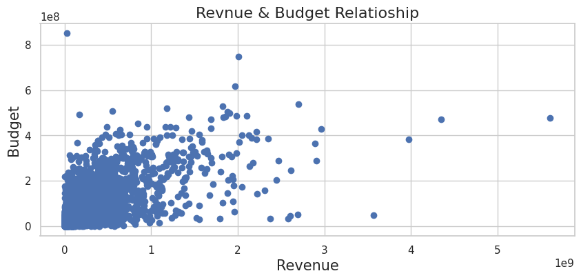

```python
# visualizing the realtionship between all budget and all revenue by scatter plot
plt.scatter(df.all_revenue, df.all_budget)
plt.xlabel('Revenue', fontsize=15)
plt.ylabel('Budget', fontsize=15)
plt.title('Revnue & Budget Relatioship', fontsize= 16)

#for the figure size.
sns.set(rc={'figure.figsize':(10,10)})
sns.set_style("whitegrid")

#find the correlation between them.
data_corr= df.corr()
print("Correlation Between revenue And budget is : ",data_corr.loc['revenue','budget'])
```

#### positive correlation(0.70)

### Q8) Which Genres Have The Highest Release Of Movies?

```python
#this function will split the string and return the count of each genre.
def data(x):
    data_plot = df[x].str.cat(sep = '|')
    data = pd.Series(data_plot.split('|'))
    #counts each of the genre and return it.
    info = data.value_counts(ascending=False)
    return info
```

```python
total_genres = data('genres')
print(total_genres)
```

```
Drama              3352
Comedy             2724
Thriller           2329
Action             1886
Horror             1285
Romance            1216
Adventure          1154
Crime              1131
Science Fiction     971
Family              824
Fantasy             682
Mystery             648
Animation           398
Music               248
History             216
War                 201
Documentary         175
Western             136
TV Movie             65
Foreign              54
dtype: int64
```

### Q9) The relationship between Popularity and Profit?

```
Correlation Between popularity And profit :  0.5799922948236683
```

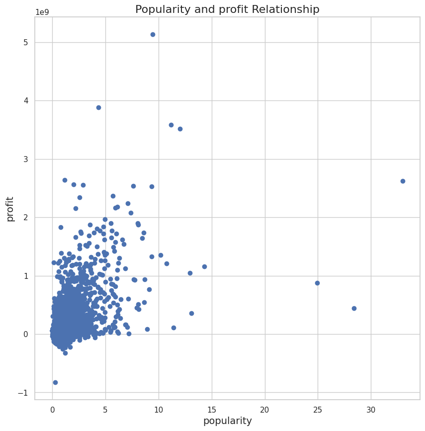

```python
#setup the lapels and the title for the scatter plot
# we get the profit in Q7
plt.scatter(df.popularity, df.profit)
plt.xlabel('popularity', fontsize=14)
plt.ylabel('profit', fontsize=14)
plt.title('Popularity and profit Relationship', fontsize= 16)

#figure size.
sns.set(rc={'figure.figsize':(10,4)})
sns.set_style("whitegrid")

#find the correlation between them.
data_corr= df.corr()
print("Correlation Between popularity And profit : ",data_corr.loc['popularity','profit'])
```

the Popularity and profit have positive correlation( 0.579)

### Q10) who are the most famous directors?

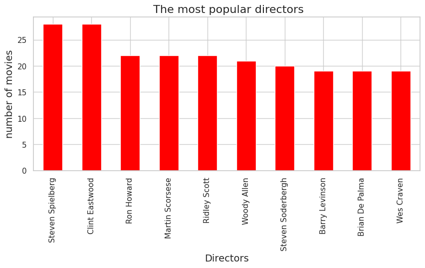

```python
Directors = df.director.value_counts().nlargest(10)
Directors.plot(kind='bar', color='red')
plt.xlabel('Directors', fontsize=14)
plt.ylabel('number of movies', fontsize=14)
plt.title(' The most popular directors', fontsize=16);
```

```python
Directors_Movies_No = df.director.value_counts().nlargest(10)
Directors_Movies_No
```

```
Steven Spielberg     28
Clint Eastwood       28
Ron Howard           22
Martin Scorsese      22
Ridley Scott         22
Woody Allen          21
Steven Soderbergh    20
Barry Levinson       19
Brian De Palma       19
Wes Craven           19
Name: director, dtype: int64
```

### the most 10 famouse directors are:

1-Steven Spielberg : 28

2-Clint Eastwood : 28

3-Ron Howard : 22

4-Martin Scorsese : 22

5-Ridley Scott : 22

6-Woody Allen : 21

7-Steven Soderbergh : 20

8-Barry Levinson : 19

9-Brian De Palma : 19

10-Wes Craven : 19

## Conclusions

1-Jurassic World

2-Mad Max: Fury Road

10-The Hunger Games: Mockingjay - Part 1

### the top 10 highest revnue movies are:

1-Avatar

2-Titanic

3-Star Wars: The Force Awakens

4-Star Wars

5-The Avengers

6-Jurassic World

7-Furious 7

8-Avengers: Age of Ultron

9-The Net

10-Harry Potter and the Deathly Hallows: Part 2

### -Top 10 highest rated movies:

1-The Jinx: The Life and Deaths of Robert Durst

2-The Shawshank Redemption

3-Stop Making Sense

4-The Godfather

5-Whiplash

6-For All Mankind

7-Bill Cunningham New York

8-Fight Club

9-The Dark Knight

10-Kill Bill: The Whole Bloody Affair

### -The most 10 famouse directors are:

1-Steven Spielberg

2-Clint Eastwood

3-Ron Howard

4-Martin Scorsese

5-Ridley Scott

6-Woody Allen

7-Steven Soderbergh

8-Barry Levinson

9-Brian De Palma

10-Wes Craven

### - Genres with The Highest Release Of Movies:

Drama 3352

Comedy 2724

Thriller 2329

Action 1886

Horror 1285

Romance 1216

Adventure 1154

Crime 1131

Science Fiction 971

Family 824

Fantasy 682

Mystery 648

Animation 398

Music 248

History 216

War 201

Documentary 175

Western 136

TV Movie 65

Foreign 54

### -the Average runtime is between (100) and (150) mins

### -positive relationship between popularity and vote_count

### -positive relationship between Popularity and Profit

## Submitting your Project

```python
# Running this cell will execute a bash command to convert this notebook to an .html file
!python -m nbconvert --to html Investigate_a_Dataset.ipynb
```

```
[NbConvertApp] Converting notebook Investigate_a_Dataset.ipynb to html
[NbConvertApp] Writing 1108434 bytes to Investigate_a_Dataset.html
```